# Algebraic Geometry

# Tuesday, November 10

## Homogenization and Dehomogenization

Note that $S(X)$ is not a ring of functions on $X$: e.g. for $X= {\mathbb{P}}^n$, $S(X) = k[x_1, \cdots, x_{n}]$ but $x_0$ is not a function on ${\mathbb{P}}^n$. This is because $f\qty{{\left[ {x_0: \cdots : x_n} \right]}} = f\qty{{\left[ {\lambda x_0: \cdots : \lambda x_n} \right]}}$ but $x_0\neq \lambda x_0$. It still makes sense to ask if $f$ is zero, so $V_p(f)$ is a well-defined object.

Let $f\in k[x_1, \cdots, x_{n}]$ be a homogeneous polynomial, then we define its dehomogenization as
$$\begin{align*} f^i \mathrel{\vcenter{:}}= f(1, x_1, \cdots, x_n) \in k[x_1,\cdots, x_n] .\end{align*}$$

For a homogeneous ideal, we define
$$\begin{align*} J^i \mathrel{\vcenter{:}}=\left\{{f^i ~{\text{s.t.}}~f\in J}\right\} .\end{align*}$$

This is usually not homogeneous. Take
$$\begin{align*} f &= x_0^3 + x_0 x_1^2 + x_0 x_1 x_2 + x_0^2 + x_1 \\ \implies f^i &= 1 +x_1^2 + x_1 x_2 + x_1 ,\end{align*}$$
where has terms of mixed degrees.

- $(fg)^i = f^i g^i$,
- $(f+g)^i = f^i + g^i$

In other words, evaluating at $x_0 = 1$ is a ring morphism.

Let $f\in k[x_1, \cdots, x_{n}]$, then the **homogenization** of $f$ is defined by
$$\begin{align*} f^h \mathrel{\vcenter{:}}= x_0^d f\qty{ {x_1 \over x_0}, \cdots, {x_n \over x_0} } \end{align*}$$
where $d\mathrel{\vcenter{:}}=\deg(f)$.

Let $f(x_1, x_2) = 1 + x_1^2 + x_1 x_2 + x_2^3$, then
$$\begin{align*} f^h(x_0, x_1, x_2) = x_0^3 + x_0 x_1^2 + x_0 x_1 x_2 + x_2^3 ,\end{align*}$$
which is a homogeneous polynomial of degree $3$. Note that $(f^h)^i = f$.

It need not be the case that $(f^i)^h = f$. Take $f = x_0^3 + x_0 x_1 x_2$, then $f^i = 1 + x_1 x_2$ and $(f^i)^h = x_0^2 + x_1 x_2$. Note that the total degree dropped, since everything was divisible by $x_0$.

$$\begin{align*} (f^i)^h = f \iff x_0 \nmid f .\end{align*}$$

Given $J\subset k[x_1, \cdots, x_{n}]$, define its **homogenization** as
$$\begin{align*} J^h \mathrel{\vcenter{:}}=\left\{{f^h ~{\text{s.t.}}~f\in J}\right\} .\end{align*}$$

This is not a ring morphism, since $(f+g)^h \neq f^h + g^h$ in general. Taking $f = x_0^2 + x_1$ and $g= -x_0^2 + x_2$, we have $f^h + g^h = x_0 x_1 + x_0 x_2$ while $(f+g)^h = x_12 + x_2$.

What is the geometric significance? Set
$$\begin{align*} U_0 \mathrel{\vcenter{:}}=\left\{{{\left[ {x_0: \cdots :x_n} \right]} \in {\mathbb{P}}^n_{/k} ~{\text{s.t.}}~x_0 \neq 0 }\right\} \cong {\mathbb{A}}^n_{/k} \end{align*}$$
with coordinates ${\left[ {{x_1\over x_0} : \cdots : {x_n \over x_0}} \right]}$.

The conclusion is thus that $U_0$ with the subspace topology is equal to ${\mathbb{A}}^n$ with the Zariski topology.

If we define the Zariski topology on ${\mathbb{P}}^n$ as having closed sets $V_p(I)$, we would want to check that ${\mathbb{A}}^n\cong U_0 \subset {\mathbb{P}}^n$ is closed in the subspace topology. This amounts to showing that $V_p(I) \cap U_0$ is closed in ${\mathbb{A}}^n \cong U_0$. We can check that
$$\begin{align*} V_p(f, f\in I) = \left\{{{\left[ {x_0:\cdots:x_n} \right]} ~{\text{s.t.}}~f(\mathbf{x}) = 0 \, \forall f\in I}\right\} .\end{align*}$$
Intersecting with $U_0$ yields $\left\{{{\left[ {x_1:\cdots:x_n} \right]} ~{\text{s.t.}}~f(\mathbf{x}) = 0,\, x_0\neq 0}\right\}$. Equivalently, we can rewrite this set as
$$\begin{align*} \left\{{{\left[ {x_1:\cdots:x_n} \right]} ~{\text{s.t.}}~f\qty{{\left[ {1, {x_1 \over x_0}, \cdots,{x_n \over x_0} } \right]}} = 0,\, f \text{ homogeneous}}\right\} \end{align*}$$
Since these are coordinates on ${\mathbb{A}}^1$, we have $V_p(I) \cap U_0 = V_a(I^i)$ which is closed.

Conversely, given a closed set $V(I)$, we can write this as $V(I) = U_0 \cap V_p(I^h)$.

${\mathbb{P}}^n$ is irreducible of dimension $n$, where the proof is that its covered by irreducible topological spaces of dimension $n$ with nonempty intersection combined with a fact from the exercises.

Consider $f(x_1, x_2) = x_1^2 - x_2^2 - 1$ and consider $V(f) \subset {\mathbb{A}}^2_{/{\mathbb{C}}}$:

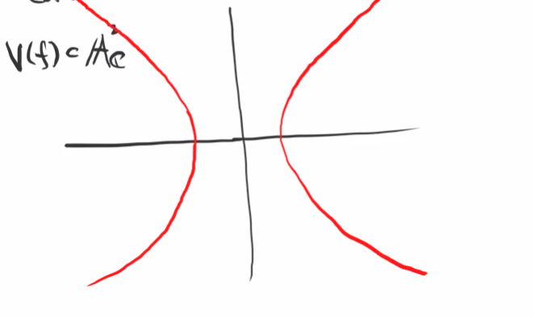

Image

Note that for real projective space, we can view this as a sphere with antipodal points identified. We can thus visualize this in the following way:

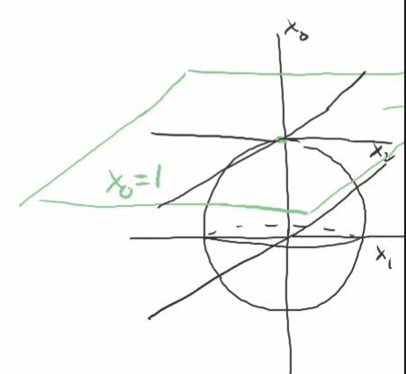

We can normalize the $x_0$ coordinate to one, hence the plane. We can also project $V(f)$ from the plane onto the sphere, mirroring to antipodal points:

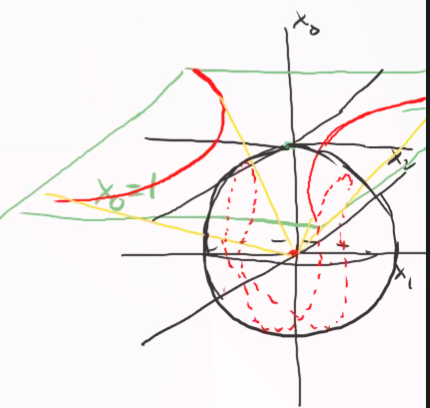

Image

This misses some points on the equator, since we aren’t including points where $x_0 = 0$. Consider the homogenization $V(f^h) \subset {\mathbb{P}}^2_{/{\mathbb{C}}}$. It’s given by $f^h = x_1^2 - x_2^2 - x_0^2$, then
$$\begin{align*} V(f^h) \cap V(x_0) = \left\{{{\left[ {0:x_1:x_2} \right]} ~{\text{s.t.}}~f^h(0, x_1, x_2) = 0 }\right\} = \left\{{{\left[ {0:1:1} \right]}, {\left[ {0:1:-1} \right]}}\right\} ,\end{align*}$$
which can be seen in the picture as the points at infinity:

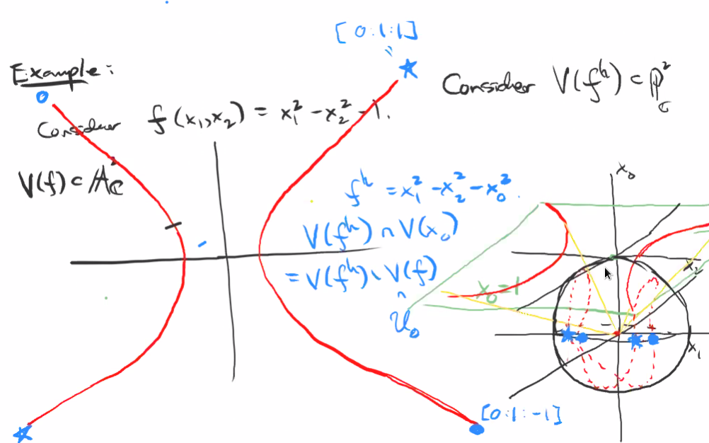

Note that the equator is $V(x_0) = {\mathbb{P}}^2_{/{\mathbb{C}}}\setminus U_0 \cong {\mathbb{P}}^2\setminus{\mathbb{A}}^2$. So we get a circle of points at infinity, i.e. $V(x_0) = {\mathbb{P}}^1 = \left\{{{\left[ {0:v_1:v_2} \right]}}\right\}$.

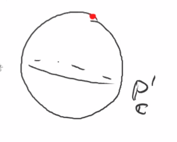

${\mathbb{P}}^1_{{\mathbb{C}}}$

${\mathbb{P}}^2_{/k}$ for any field $k$ is a **projective plane**, which satisfies certain axioms:

1. There exists a unique line through any two distinct points,
2. Any two distinct lines intersect at a single point.

A famous example is the *Fano plane*:

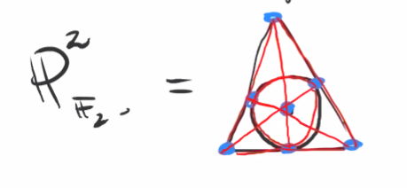

Fano Plane

Why is this true? ${\mathbb{P}}^2_{/k}$ is the set of lines in $k^3$, and the lines in ${\mathbb{P}}^2_{/k}$ are the vanishing loci of homogeneous polynomials and also planes in $k^3$, since any two lines determine a unique plane and any two planes intersect at the origin.

Let $J\subset k[x_1, \cdots, x_{n}]$ be an ideal. Let $X \mathrel{\vcenter{:}}= V_a(J) \subset {\mathbb{A}}^n$ where we identify ${\mathbb{A}}^n = U_0 \subset {\mathbb{P}}^n$. Then the closure $\mkern 1.5mu\overline{\mkern-1.5muX\mkern-1.5mu}\mkern 1.5mu \subset {\mathbb{P}}^n$ is given by $\mkern 1.5mu\overline{\mkern-1.5muX\mkern-1.5mu}\mkern 1.5mu = V_p(J^h)$. In particular, $V_a(J) = V_p(J^h)$.

Note that it’s clear that $V_p(J^h)$ is closed and contains $V_a(J)$. For the reverse containment, let $Y\supseteq X$ be closed; we want to show that $Y\supseteq V_p(J^h)$. Since $Y$ is closed, $Y = V_p(J')$ where $J'$ is some homogeneous ideal. Any element $f'\in J'$ satisfies $f' = x^d f$ for some maximal $d$ where $x_0^d f$ vanishes on $X$. We also have $f=0$ on $X$ since $X\subset U_0$. We can compute
$$\begin{align*} f\in I_a(X) = I_a(V_a(J)) = \sqrt J ,\end{align*}$$
so $f^m\in J$. Then $(f^h)^m \in J^h$ for some $m$, and this $f^h \in \sqrt{J^h}$.

We can conclude that $J'\subset \sqrt J$, which shows that $V_p(J') \supseteq V_p(J^h)$ as desired.

The **projective closure** of $X = V_a(J)$ is the smallest closed subset containing $X$ and is given by
$$\begin{align*} \mkern 1.5mu\overline{\mkern-1.5muX\mkern-1.5mu}\mkern 1.5mu = V_p(J^h) .\end{align*}$$

# Thursday, November 12

Recall that if $f\in k[x_1, \cdots, x_{n}]$ is a homogeneous degree $d$ polynomial, then $f^i \mathrel{\vcenter{:}}= f(1, x_1, \cdots, x_n) \in k[x_1,\cdots, x_n]$ is the dehomogenization of $f$. Conversely, $f^h \mathrel{\vcenter{:}}= x_0^d f\qty{ {x_1 \over x_0}, \cdots, {x_n \over x_0} }$ is the homogenization. This is related to looking at the open subset $U_0 \mathrel{\vcenter{:}}={\left\{{x}\right\}\in {\mathbb{P}}^n_{/k} ~{\text{s.t.}}~x_0\neq 0} \subseteq {\mathbb{P}}^n_{/k}$, where we found that $U_0 \cong {\mathbb{A}}^n_{/k}$.

Let $V(I) \subset U_0$ be an affine variety, then $V(I) \subset {\mathbb{P}}^n_{/k}$ is given by
$$\begin{align*} V(I^h) \mathrel{\vcenter{:}}=\left\{{f^h ~{\text{s.t.}}~f\in I}\right\} ,\end{align*}$$
the **projective closure**.

Projective varieties are better! They’re closed in the classical topology, and subsets of projective space and thus compact.

It doesn’t suffice to just homogenize the individual generators of the ideal $I$. For example, take $J \mathrel{\vcenter{:}}=\left\langle{x_1, x_2 - x_1^2}\right\rangle$. We have $V(J) \subset {\mathbb{A}}^2$ given by $\left\{{(0, 0)}\right\}$, and by the proposition, $V(J^h) = \left\{{[1:0:0]}\right\}$ since the single point at the origin is closed in ${\mathbb{P}}^2$.

On the other hand,
$$\begin{align*} V_p(x_1, x_0 x_2 - x_1^2) = \left\{{[1:0:0], [0:0:1]}\right\} \subset {\mathbb{P}}^2 .\end{align*}$$

Note that $x_2 \in J$, so this needs to be homogenized too.[^2]

An aside: how do you implement algebraic geometry? For example, when is $\left\langle{f_i}\right\rangle = \left\langle{1}\right\rangle$? This is generally a somewhat difficult problem, since checking that their corresponding varieties are equal isn’t so tractable.

## Chapter ?

Goal: understand and define the sheaf of regular functions on projective varieties. Given an open subset $U\subset V_p(J)$, what are the regular functions on it?

Let $U\subset X$ be an open subset of a projective variety, and define
$$\begin{align*} {\mathcal{O}}_X(U) \mathrel{\vcenter{:}}=\left\{{\phi:U\to k ~{\text{s.t.}}~\phi \text{ is locally of the form } {g_p \over f_p} \in S(X)_d }\right\} .\end{align*}$$
i.e. the functions in the homogeneous coordinate ring of the same degree $d$.

Note that $g_p/f_p$ is well-defined on $V(f_p)^c$ since
$$\begin{align*} { g_p(\lambda \mathbf{x}) \over f_p(\lambda \mathbf{x})} = { \lambda^d g_p(\mathbf{x}) \over \lambda^d f_p(\mathbf{x}) } = {g_p(\mathbf{x}) \over f_p (\mathbf{x})} \end{align*}$$

Recall that “locally of the form $\cdots$” means that for all $p\in U$, there exists an open neighborhood $U_p$ on which ${\left.{\phi}\right|_{U_p}} = g_p / f_p$.

Note that if $X\subset {\mathbb{P}}^n$ is closed, then $X\cap U_i$ is closed and thus an affine variety.
$$\begin{align*} \tilde {\mathcal{O}}_X(U) \mathrel{\vcenter{:}}=\left\{{\phi: U\to k ~{\text{s.t.}}~{\left.{\phi}\right|_{U\cap U_i}} \text{ is a regular function} }\right\} .\end{align*}$$

These two definitions are equivalent.

It suffices to check that ${\mathcal{O}}_{X\cap U_i} = \tilde {\mathcal{O}}_{X\cap U_i}$ as sheaves on $X\cap U_i$, i.e. checking on an open cover, since then they’d both arise from the gluing construction. We have
$$\begin{align*} X\cap U_i = \left\{{[x_0 : \cdots: x_n] ~{\text{s.t.}}~x_i \neq 0 }\right\} .\end{align*}$$

Let $V\subset X\cap U_0$ be an open subset, we then want to show that ${\mathcal{O}}_X(V)$ are the regular functions on $V$ when $V$ as a subset of an affine variety. So let $\phi\in {\mathcal{O}}_X(V)$, so that locally $\phi = g_p/f_p \in S(X)_d$ as a ratio of two homogeneous polynomials. We want to know if $\phi$ can be written as the ratio of two polynomials in one additional variable, so we just dehomogenize to obtain $\phi = g^i_p / f^i_p$ locally where both are in $A(X\cap U_0)$. So $\phi$ is a regular function on the open subset $V$ of the affine variety $X\cap U_0$.

Conversely, suppose that $\phi = g_p/f_p \in A(X\cap X_0)$ locally around $p$. It’s not necessarily the case that $\phi = g^h_p / f^h_p$, but it is true that
$$\begin{align*} \phi = {x_0^d g_p^h \over f_p^h} = {g_p^h \over x_0^{-d} f_p^h} ,\end{align*}$$
where $d = \deg f^h - \deg g^h$. This is locally a ratio of two homogeneous polynomials of equal degree, so ${\mathcal{O}}_X$ and $\tilde {\mathcal{O}}_X$ define the same sheaf of functions on $X$.

## Morphisms of Projective Varieties

Let $X$ be a projective variety and $f_0, \cdots, f_m \in S(X)_d$. Then on the open subset $X\setminus V(f_i)$, there is a morphism
$$\begin{align*} f: U &\to {\mathbb{P}}^m \\ p &\mapsto {\left[ {f_0(p) : \cdots : f_m(p) } \right]} .\end{align*}$$

This map is well-defined, since letting $p = [x_0: \cdots : x_n]$ we have
$$\begin{align*} [\lambda x_0 : \cdots : \lambda x_n] &\mapsto [ \lambda^d f_0(p) : \cdots : \lambda^d f_m(p)] = f(p) .\end{align*}$$

We need to check that

1. $f$ is continuous, and
2. The pullback of a regular function on any open set is again regular.

$f$ is continuous.

Consider $f^{-1}(V(h))$ with $h\in k[y_0, \cdots, y_m]$ homogeneous. We can check that
$$\begin{align*} f^{-1}(V_p(h)) = V_p(h(f_0, \cdots, f_m)) ,\end{align*}$$
which is closed, so $f$ is continuous.

$f$ pulls back regular functions.

Let $h_1, h_2 \in S({\mathbb{P}}^m)$ be homogeneous polynomials of equal degree in $k[y_0, \cdots, y_m]$. Then on $V(h_2)^c$, we have
$$\begin{align*} f^*\qty{h_1 \over h_2 } = {h_1(f_0, \cdots, f_m) \over h_2(f_0, \cdots, f_m)} .\end{align*}$$
This is a ratio of homogeneous polynomials of equal degree in the $x_i$, the pullback is again locally homogeneous ratios of functions of equal degree.

# Misc Unsorted

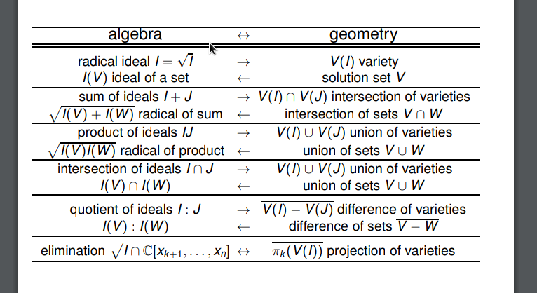

Image

Gathmann, A. (2019). *Algebraic geometry*.